# Reproducción de resultados

Mariana Gómez Becerra, Mayra Lizeth Barcenas Guevara

2026-05-19

# Proyecto genómica funcional

```r
# Le pedimos a la IA que nos diera código para poner dos imágenes juntas en el mismo renglón
```

```r
# Preparar el entorno. Asegurate que tienes instalados estos paquetes antes de correr el código.

library(dada2)
```

```r
library(phyloseq)
library(ggplot2)
library(igraph)
library(corrr)
library(ggraph)
library(tidygraph)
```

Seguimos un pipeline de DADA2 para obtener la asignación taxonómica de hongos y bacterias, con datos de secuenciación (ITS2 y 16S, respectivamente):

Quality profile -> Filter and Trim -> Learn Errors -> dada (Divisive Amplicon Denoising Algorithm) -> Merge pairs -> Remove Bimera -> Assign Taxonomy

Analizamos 275 muestras de bacterias, y 275 muestras de hongos, con millones de lecturas en total.

Para bacterias, estos fueron nuestros perfiles de calidad:

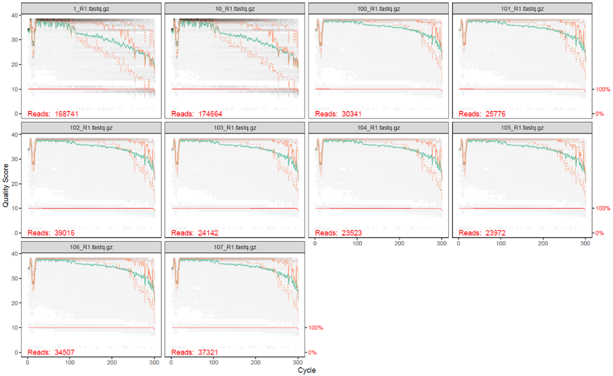

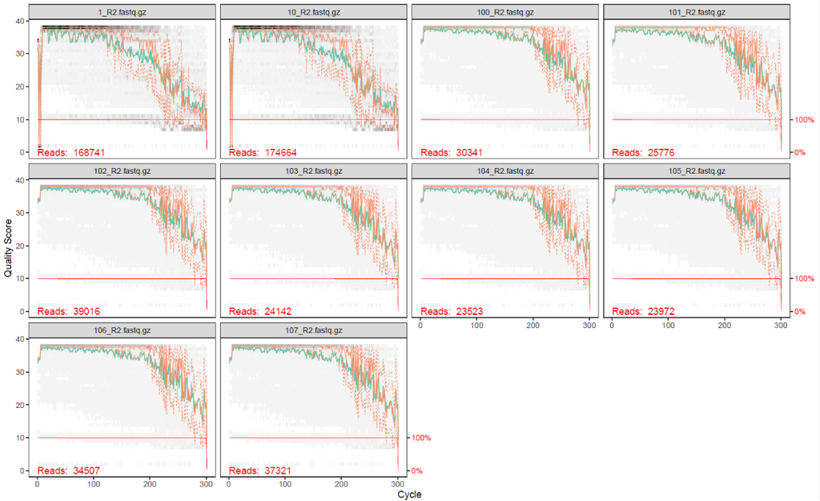

Y estos fueron los de hongos:

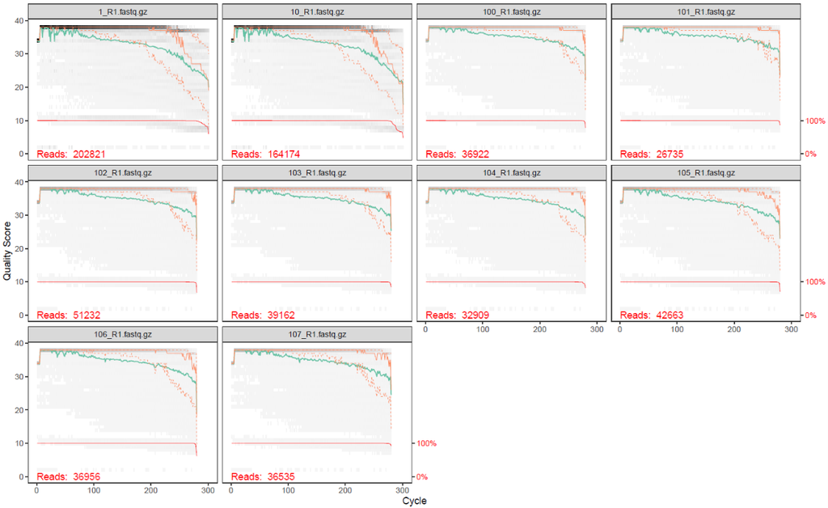

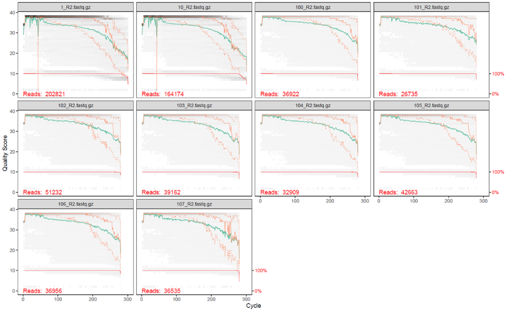

Después de filtrar las secuencias, el algoritmo de machine learning genera un modelo de error basado en los datos (learnErrors). La calidad del modelo se observa con plotErrors, donde los puntos son las tasas de error observadas, y la línea negra es el error estimado por el modelo, deben estar muy cercanos los puntos a esta línea. La línea roja son las tasas de error esperadas con cada Phred score.

En bacterias:

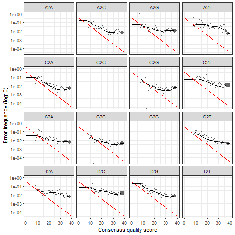

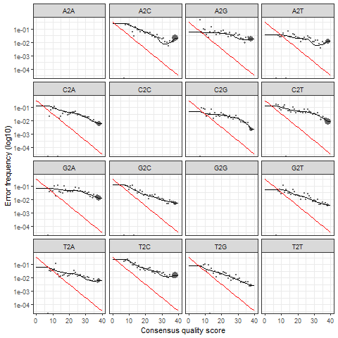

Y en hongos:

[figure not shown]

[figure not shown]

Seguimos adelante con la asignación taxonómica de bacterias, pero por cuestiones de tiempo, no hicimos asignación de hongos. A partir de aquí todos los resultados son exclusivamente de bacterias.

Ya que obtuvimos la asignación final, revisamos si se logró asignar hasta nivel de especie, y no se pudo:

```r
taxa.print_b[,7]
```

```
##   [1] NA NA NA NA NA NA NA NA NA NA NA NA NA NA NA NA NA NA NA NA NA NA NA NA NA
##  [26] NA NA NA NA NA NA NA NA NA NA NA NA NA NA NA NA NA NA NA NA NA NA NA NA NA
##  [51] NA NA NA NA NA NA NA NA NA NA NA NA NA NA NA NA NA NA NA NA NA NA NA NA NA
##  [76] NA NA NA NA NA NA NA NA NA NA NA NA NA NA NA NA NA NA NA NA NA NA NA NA NA
## [101] NA NA NA NA NA NA NA NA NA NA NA NA NA NA NA NA NA NA NA NA NA NA NA NA NA
## [126] NA NA NA NA NA NA NA NA NA NA NA NA NA NA NA NA NA NA NA NA NA NA NA NA NA
## [151] NA NA NA NA NA NA NA NA NA NA NA NA NA NA NA NA NA NA NA NA NA NA NA NA NA
## [176] NA NA NA NA NA NA NA NA NA NA NA NA NA NA NA NA NA NA NA NA NA NA NA NA NA
## [201] NA NA NA NA NA NA NA NA NA NA NA NA NA NA NA NA NA NA NA NA NA NA NA NA NA
## [226] NA NA NA NA NA NA NA NA NA NA NA NA NA NA NA NA NA NA NA NA NA NA NA NA NA
## [251] NA NA NA NA NA NA NA NA NA NA NA NA NA NA NA NA NA NA NA NA NA NA NA NA NA
## [276] NA NA NA NA NA NA NA NA NA NA NA NA NA NA NA NA NA NA NA NA NA NA NA NA NA
## [301] NA NA NA NA NA NA NA NA NA NA NA NA NA NA NA NA NA NA NA NA NA NA NA NA NA
## [326] NA NA NA NA NA NA NA NA NA NA NA NA NA NA NA NA NA NA NA NA NA NA NA NA NA
## [351] NA NA NA NA NA NA NA NA NA NA NA NA NA NA NA NA NA NA NA NA NA NA NA NA NA
## [376] NA NA NA NA NA NA NA NA NA NA NA NA NA NA NA NA NA NA NA NA NA NA NA NA NA
## [401] NA NA NA NA NA NA NA NA NA NA NA NA NA NA NA NA NA NA NA NA NA NA NA NA NA
## [426] NA NA NA NA NA NA NA NA NA NA NA NA NA NA NA NA NA NA NA NA NA NA NA NA NA
## [451] NA NA NA NA NA NA NA NA NA NA NA NA NA NA NA NA NA NA NA NA NA NA NA NA NA
## [476] NA NA NA NA NA NA NA NA NA NA NA NA NA NA NA NA NA NA NA NA NA NA NA NA NA
## [501] NA NA NA NA NA NA NA NA NA NA NA NA NA NA NA NA NA NA NA NA NA NA NA NA NA
## [526] NA NA NA NA NA NA NA NA NA NA NA NA NA NA NA NA NA NA NA NA NA NA NA NA NA
## [551] NA NA NA NA NA NA NA NA NA NA NA NA NA NA NA NA NA NA NA NA NA NA NA NA NA
## [576] NA NA NA NA NA NA NA NA NA NA NA NA NA NA NA NA NA NA NA NA NA NA NA NA NA
## [601] NA NA NA NA NA NA NA NA NA NA NA NA NA NA NA NA NA NA NA NA NA NA NA NA NA
## [626] NA NA NA NA NA NA NA NA NA NA NA NA NA NA NA NA NA NA NA NA NA NA NA NA NA
## [651] NA NA NA NA NA NA NA NA NA NA NA NA NA NA NA NA NA NA NA NA NA NA NA NA NA
## [676] NA NA NA NA NA NA NA NA NA NA NA NA NA NA NA NA NA NA NA NA NA NA NA NA NA
## [701] NA NA NA NA NA NA NA NA NA NA NA NA NA NA NA NA NA NA NA NA NA NA NA NA NA
## [726] NA NA NA NA NA NA
```

Pero varios sí llegaron a nivel de género:

```r
taxa.print_b[90:100, 1:6]
```

```
##       Kingdom     Phylum            Class            Order
##  [1,] "Eukaryota" NA                NA               NA
##  [2,] "Bacteria"  "Acidobacteriota" "Blastocatellia" "Pyrinomonadales"
##  [3,] "Eukaryota" NA                NA               NA
##  [4,] "Eukaryota" NA                NA               NA
##  [5,] "Bacteria"  "Acidobacteriota" "Blastocatellia" "Pyrinomonadales"
##  [6,] "Eukaryota" NA                NA               NA
##  [7,] "Eukaryota" NA                NA               NA
##  [8,] "Bacteria"  "Acidobacteriota" "Blastocatellia" "Pyrinomonadales"
##  [9,] "Bacteria"  "Actinomycetota"  "Rubrobacteria"  "Rubrobacterales"
## [10,] "Bacteria"  "Actinomycetota"  "Actinobacteria" "Mycobacteriales"
## [11,] "Bacteria"  "Actinomycetota"  "Actinobacteria" "Pseudonocardiales"
##       Family               Genus
##  [1,] NA                   NA
##  [2,] "Pyrinomonadaceae"   NA
##  [3,] NA                   NA
##  [4,] NA                   NA
##  [5,] "Pyrinomonadaceae"   "Arenimicrobium"
##  [6,] NA                   NA
##  [7,] NA                   NA
##  [8,] "Pyrinomonadaceae"   "Brevitalea"
##  [9,] "Rubrobacteriaceae"  "Rubrobacter"
## [10,] "Mycobacteriaceae"   "Mycobacterium"
## [11,] "Pseudonocardiaceae" "Pseudonocardia"
```

A partir de los datos generados por DADA2, creamos un objeto phyloseq para hacer el filtrado de ASVs:

```r
print (ps)
```

```
## phyloseq-class experiment-level object
## otu_table()   OTU Table:         [ 731 taxa and 237 samples ]
## sample_data() Sample Data:       [ 237 samples by 2 sample variables ]
## tax_table()   Taxonomy Table:    [ 731 taxa by 7 taxonomic ranks ]
```

Posteriormente analizamos la distribución de las lecturas:

```r
summary(sample_sums_vec)
```

```
##    Min. 1st Qu.  Median    Mean 3rd Qu.    Max.
##   0.000   0.000   3.000   8.046  13.000  79.000
```

- Min 0: indica que hubo al menos una muestra con 0 lecturas
- 1st Qu. 0: indica que hasta el primer cuartil (25%), ninguna muestra tenía lecturas
- Median (2nd Qu) 3: indica que hasta el segundo cuartil (50%), las muestras tienen máximo 3 lecturas
- 3rd Qu 13: indica que hasta el tercer cuartil (75%), las muestras tienen máximo 13 lecturas.
- Max 79: indica que hubo al menos una muestra con 79 lecturas, y ninguna muestra tuvo más
- Mean 8: en promedio las muestras tuvieron 8 lecturas, lo cual es muy malo, porque inicialmente se tenían más de 100 millones de lecturas.

Se perdió mucha información al momento de hacer la asignación taxonómica, probablemente por usar parámetros demasiado estrictos.

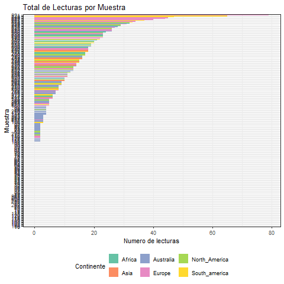

Distribución de bacterias

```r
sum (sample_sums_vec)
```

```
## [1] 1907
```

Nosotros nos quedamos con 1907 lecturas. Y el autor original se quedó con 6,278,448 lecturas en este paso.

```r
ntaxa(ps)
```

```
## [1] 731
```

Al final de la asignación obtuvimos 731 ASV (el autor original se quedó con 60,538 ASV de bacterias)

Puesto que la cantidad de ASV que obtuvimos fue muy poca, no realizamos el filtrado estricto que se usa en el artículo original, si no que usamos uno más permisivo para no perder tantos ASVs:

- Se eliminaron los ASV con solo 1 lectura.
- No se hizo filtrado por prevalencia en los continentes (el artículo original usó 25%)

## Conclusiones

### Extrapolable a otros proyectos

- La literatura en bioinformática carece de metologías bien descritas que permitan una reproducción adecuada de los resultados.
- Al trabajar con metodologías tardadas, en trabajos colaborativos o que involucren el uso de distintas computadoras para el mismo proyecto, es recomendable generar “checkpoints”durante todo el proceso, para facilitar el trabajo y evitar repetir pasos.